# Caso Práctico 5: Colgate vs. Crest

Marcos Barragán

20/11/2020

## Objetivos:

El objetivo de esta práctica es llevar a cabo un análisis de las cuotas de mercado semanales de Colgate y Crest de los datos proporcionados, que van desde 1958 hasta 1963. Se escoge este período porque en él aparecen los efectos del marketing que la Asociación de Dentistas de Estados Unidos brindó a Crest al incliuirlo como una “ayuda importante en cualquier programa de higiene dental”.

Se empleará un modelo ARIMA y unos modelos ARIMAX con análisis de intervención y búsqueda de outliers, para finalmente incluir una función de transferencia que genere un modelo que prediga los resultados de las cuotas de ambas firmas para las 16 primeras semanas de 1963.

## Esquema:

- Series temporales
- Modelos ARIMA
- Modelos ARIMAX y análisis de intervención.
- Función de transferencia.

#Cargamos las librerías que necesitamos:

Leemos los datos que nos proporcionan para esta práctica y mostramos la cabecera de los mismos:

| Year | Week | Crest | Colgate |
| --- | --- | --- | --- |
| 1958 | 1 | 0.108 | 0.424 |
| 1958 | 2 | 0.166 | 0.482 |
| 1958 | 3 | 0.126 | 0.428 |
| 1958 | 4 | 0.115 | 0.397 |
| 1958 | 5 | 0.119 | 0.352 |
| 1958 | 6 | 0.176 | 0.342 |

Transformamos las fechas a formato xts semanal, obteniendo unas entradas:

```
##            xCrest.Open xCrest.High xCrest.Low xCrest.Close
## 1958-01-08       0.108       0.108      0.108        0.108
## 1958-01-15       0.166       0.166      0.166        0.166
## 1958-01-22       0.126       0.126      0.126        0.126
## 1958-01-29       0.115       0.115      0.115        0.115
## 1958-02-05       0.119       0.119      0.119        0.119
## 1958-02-12       0.176       0.176      0.176        0.176
```

```
##            xColgate.Open xColgate.High xColgate.Low xColgate.Close
## 1958-01-08         0.424         0.424        0.424          0.424
## 1958-01-15         0.482         0.482        0.482          0.482
## 1958-01-22         0.428         0.428        0.428          0.428
## 1958-01-29         0.397         0.397        0.397          0.397
## 1958-02-05         0.352         0.352        0.352          0.352
## 1958-02-12         0.342         0.342        0.342          0.342
```

Nos quedamos únicamente con los valores de cierre de las cuotas de Crest y Colgate:

- Datos para Crest:

| Cuotas |
| --- |
| 0.108 |
| 0.166 |
| 0.126 |
| 0.115 |
| 0.119 |
| 0.176 |

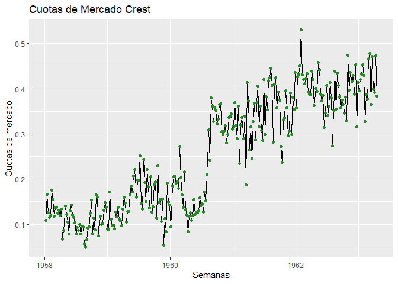

En el gráfico se aprecia lo que se comenta en el caso práctico, y es que el 1 de agosto de 1960, el Consejo de Terapéutica Dental de la American Dental Association (ADA) aprobó a Crest como una “ayuda importante en cualquier programa de higiene dental”. Es por ello que aparece una fuerte subida de la cuota de mercado de Crest.

- Para el caso de Colgate:

| Cuotas |
| --- |
| 0.424 |
| 0.482 |
| 0.428 |
| 0.397 |
| 0.352 |
| 0.342 |

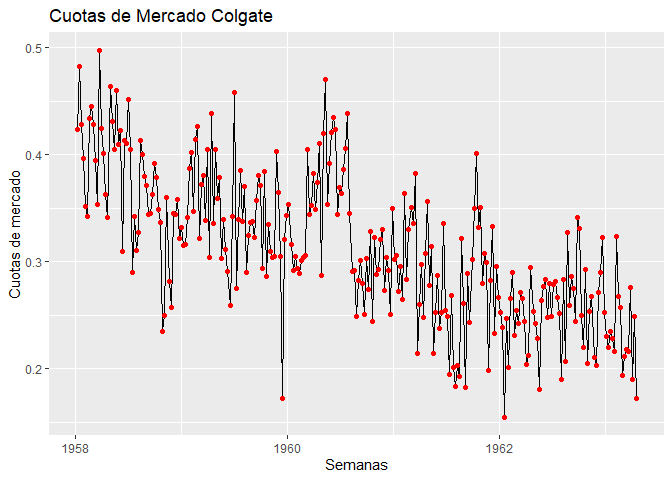

En este gráfico, vemos como en las últimas semanas de 1959 aparece un punto mucho conflictivo, que, para mi caso, es el punto 102. Lo intentaré implementar después al hacer el modelo con intervención.

Entre las principales caracteristicas se encuentran: la serie temporal de Crest tiene tendencia creciente, y da un salto en 1960, donde da un impulso pero no se estabiliza con respecto a las medias, lo que denota que es un evento escalón. Otras caracteristicas que tiene es que no es estacionaria ni estacional. En el caso de Colgate-Palmolive, también tiene el efecto del escalón en 1960 pero en sentido decreciente y no es estacionaria ni estacional.

Quitamos los 16 datos de 1963 antes de comenzar a implementar los modelos ARIMA y ARIMAX.

### Modelos ARIMA

Para hacer el modelo ARIMA, estudiaré a continuación qué valor de $\lambda$ es el que nos devuelve el máximo del logaritmo de la función de máxima verosimilitud. Esto se estudia a partir del test de Box-Cox.

A continuación, implementaré los modelos ARIMA correspondientes a los datos de entrenamiento de Crest y Colgate. En particular, utilizaré el valor de $\lambda$ automático, que implementa en sí mismo un test de Box-Cox para devolver el máximo del logaritmo de la función de máxima verosimilitud.

```
## Series: muestra_Crest
## ARIMA(0,1,1)
## Box Cox transformation: lambda= 0.4264684
##
## Coefficients:
##           ma1
##       -0.6375
## s.e.   0.0456
##
## sigma^2 estimated as 0.01145:  log likelihood=211.62
## AIC=-419.24   AICc=-419.19   BIC=-412.13
##
## Training set error measures:
##                       ME       RMSE        MAE       MPE     MAPE      MASE
## Training set 0.004547777 0.04548383 0.03472361 -2.039325 17.20882 0.1416423
##                    ACF1
## Training set -0.0508866
```

Para Crest, el mejor modelo es el (0, 1, 1). En este, caso dicho modelo se hace para un $\lambda = 0.426$, y presenta un $\sigma^{2}_{estimado} = 0.0114$, un $AIC = -419.24$.

```
## Series: muestra_Colgate
## ARIMA(0,1,1)
## Box Cox transformation: lambda= 1.008572
##
## Coefficients:
##           ma1
##       -0.7586
## s.e.   0.0467
##
## sigma^2 estimated as 0.002267:  log likelihood=421.15
## AIC=-838.3   AICc=-838.25   BIC=-831.18
##
## Training set error measures:
##                        ME       RMSE        MAE       MPE     MAPE      MASE
## Training set -0.002631303 0.04790194 0.03775726 -3.059068 12.79197 0.1188499
##                    ACF1
## Training set 0.05182688
```

Si mostramos un correlograma de los residuos para los modelos ARIMA de ambas variables, tendremos:

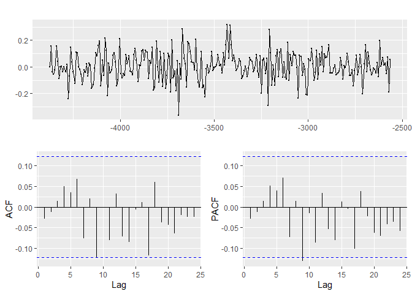

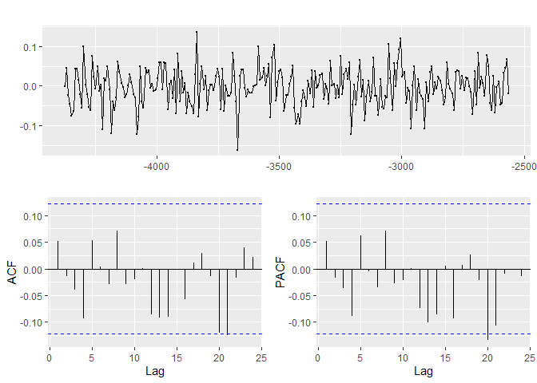

A priori, vemos que los residuos parecen comportarse como ruido blanco. Sin embargo, lo comprobaré explícitamente a través del test de Ljung-Box. Este modelo toma como hipótesis nula que los errores/residuos se comportan como ruido blanco. En función del $p_{value}$ obtenido podremos aceptar o rechazar esta hipótesis.

| P-value Arima Crest | P-value Arima Colgate |
| --- | --- |
| 0.5727828 | 0.4390797 |

Los $p_{values}$ obtenidos para el test Box-Ljung ($p_{value}=0.5728$ y $p_{value}=0.4391$ respectivamene) nos dicen que no podemos rechazar la hipótesis nula, por lo que podemos considerar los residuos del modelo **como ruido blanco**.

El siguiente paso es identificar si se tiene outliers aditivos (que afectan la serie temporal) e innovativos (que afectan el error).

```
##              [,1]       [,2]
## ind     135.00000 136.000000
## lambda2   3.81676   4.063241
```

```
## [1] "No IO detected"
```

Para el caso de Crest se identifica la intervención de ADA como un outlier aditivo (Observación 135). También se encontraron otros outliers aditivos pero podrían ser efectos de la observación 135. No se han identificado outliers innovativos.

```
## [1] "No AO detected"
```

```
## [1] "No IO detected"
```

En el caso de Colgate no se detectaron outliers aditivos ni innovativos.

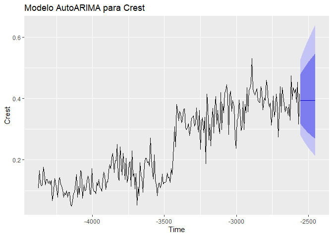

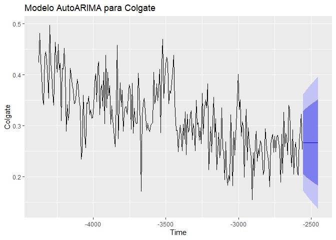

A la vista de los gráficos es evidente que las predicciones son nefastas. Los modelos ARIMA que selecciona el comando auto.arima no son válidos para nuestros casos.

Una vez conocemos todos estos resultados, lo que haré será plantear el modelo ARIMAX correspondiente a este caso.

### Modelos ARIMAX

- ARIMAX Crest:

```
##
## Call:
## arimax(x = muestra_Crest, order = c(0, 1, 1), seasonal = list(order = c(1, 0,
##     0), period = 52), method = "ML", xtransf = data.frame(I135 = 1 * (seq(muestra_Crest) ==
##     135), I136 = 1 * (seq(muestra_Crest) >= 136)), transfer = list(c(0, 0),
##     c(1, 0)))
##
## Coefficients:
##           ma1    sar1  I135-MA0  I136-AR1  I136-MA0
##       -0.7571  0.0672    0.0597    0.3229    0.1307
## s.e.   0.0450  0.0677    0.0430    0.2499    0.0435
##
## sigma^2 estimated as 0.001839:  log likelihood = 447.64,  aic = -885.28
```

Si representamos los resultados del ARIMAX estimado para Crest:

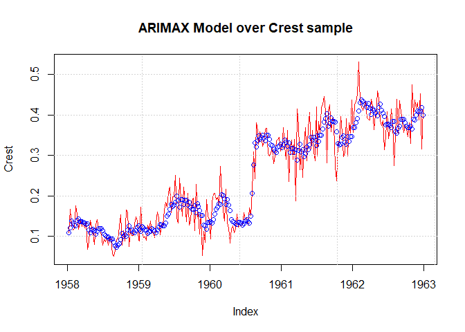

|  | Coefficients |
| --- | --- |
| ma1 | -0.7570923 |
| sar1 | 0.0672134 |
| I135-MA0 | 0.0596661 |
| I136-AR1 | 0.3228525 |
| I136-MA0 | 0.1307044 |

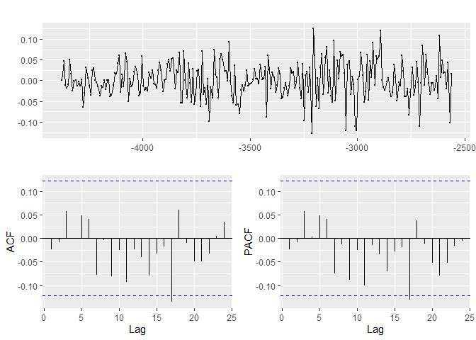

[output not shown]

```
## [1] "No AO detected"
```

```
## [1] "No IO detected"
```

- ARIMAX Colgate:

En mi caso, para implementar la intervención del modelo de Colgate he considerado el valor de la observación 135 como escalón, que coincide con el anuncio de ADA, pero, además, le he introducido un outlier “manualmente” en la observación 102 de la muestra del dataset, que coincide con la semana 50 de 1959. La pongo porque me ha sorprendido que no aparezca en el análisis de IO y AO hecho, pues es un valor outlier bastante claro. Una vez hechas estas consideraciones, lo que obtenemos es:

```
##
## Call:
## arimax(x = muestra_Colgate, order = c(0, 1, 1), seasonal = list(order = c(1,
##     0, 0), period = 52), method = "ML", xtransf = data.frame(I135 = 1 * (seq(muestra_Colgate) >=
##     135), I102 = 1 * (seq(muestra_Colgate) == 102)), transfer = list(c(1, 0),
##     c(0, 0)))
##
## Coefficients:
##           ma1    sar1  I135-AR1  I135-MA0  I102-MA0
##       -0.7961  0.0268    0.4184   -0.0690   -0.1589
## s.e.   0.0459  0.0709    0.2632    0.0308    0.0432
##
## sigma^2 estimated as 0.002077:  log likelihood = 431.85,  aic = -853.71
```

Representando lo obtenido para el modelo ARIMAX de Colgate, tendremos:

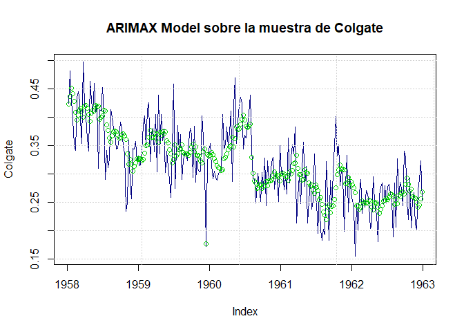

|  | Coefficients |
| --- | --- |
| ma1 | -0.7961041 |
| sar1 | 0.0268334 |
| I135-AR1 | 0.4184356 |
| I135-MA0 | -0.0690107 |
| I102-MA0 | -0.1589261 |

En el gráfico vemos cómo ajusta perfectamente el outlier de la penúltima semana de 1959, así como que el resto de puntos se adecúa bastante bien con el comportamiento de la serie.

Después de implementar el modelo ARIMAX construido anteriormente, observaremos cómo no aparecen más outliers aditivos ni innovativos.

```
## [1] "No AO detected"
```

```
## [1] "No IO detected"
```

Como antes, si analizamos los residuos generados en el modelo ARIMAX:

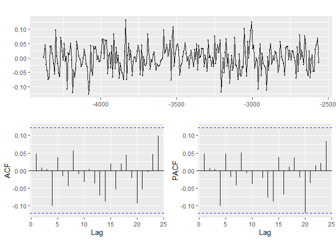

[output not shown]

Como el caso de Crest, los residuos se pueden considerar ruido blanco, por lo que el modelo es estadísticamente válido. Además, como comentaba también en el caso anterior, el hecho de que no aparezcan outliers de ningún tipo tras el modelo, nos dice que el modelo ARIMAX implementado es válido, por lo que no continuaré introduciendo más correcciones sobre el mismo.

### Función de transferencia:

```
##
## Call:
## arimax(x = dColgate135, order = c(0, 1, 1), include.mean = TRUE, method = "ML",
##     xtransf = dCrest135, transfer = list(c(0, 16)))
##
## Coefficients:
##           ma1  Cuotas-MA0  Cuotas-MA1  Cuotas-MA2  Cuotas-MA3  Cuotas-MA4
##       -1.0000     -0.5076     -0.0437     -0.0163     -0.0145      0.1006
## s.e.   0.0104      0.0714      0.0868      0.0931      0.0943      0.0948
##       Cuotas-MA5  Cuotas-MA6  Cuotas-MA7  Cuotas-MA8  Cuotas-MA9  Cuotas-MA10
##          -0.0212      0.0864      0.0255     -0.0144     -0.0028      -0.0403
## s.e.      0.0945      0.0939      0.0938      0.0937      0.0948       0.0950
##       Cuotas-MA11  Cuotas-MA12  Cuotas-MA13  Cuotas-MA14  Cuotas-MA15
##            0.0146      -0.0077       0.0650       0.0212      -0.0721
## s.e.       0.0956       0.0958       0.0955       0.0942       0.0878
##       Cuotas-MA16
##            0.0271
## s.e.       0.0730
##
## sigma^2 estimated as 0.002528:  log likelihood = 377.5,  aic = -719.01
##
## Training set error measures:
##                       ME       RMSE        MAE      MPE     MAPE      MASE
## Training set 0.001975847 0.05017277 0.03838012 78.56141 164.1255 0.4878348
##                    ACF1
## Training set -0.4224649
```

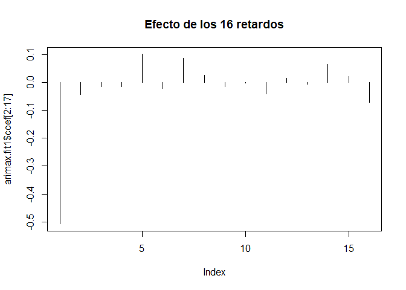

b = 0

r = 0

s = 1

```
##
## Call:
## arimax(x = dColgate135, order = c(0, 1, 1), seasonal = list(order = c(1, 0,
##     0), period = 52), include.mean = TRUE, fixed = c(NA, NA, 0, NA), method = "ML",
##     xtransf = dCrest135, transfer = list(c(0, 1)))
##
## Coefficients:
##           ma1    sar1  Cuotas-MA0  Cuotas-MA1
##       -1.0000  0.0632           0      0.2367
## s.e.   0.0096  0.0678           0      0.0653
##
## sigma^2 estimated as 0.003274:  log likelihood = 367.74,  aic = -729.49
##
## Training set error measures:
##                       ME       RMSE        MAE     MPE    MAPE      MASE
## Training set 0.001847371 0.05710883 0.04413875 90.5449 125.066 0.5610305
##                   ACF1
## Training set -0.382043
```

[output not shown]

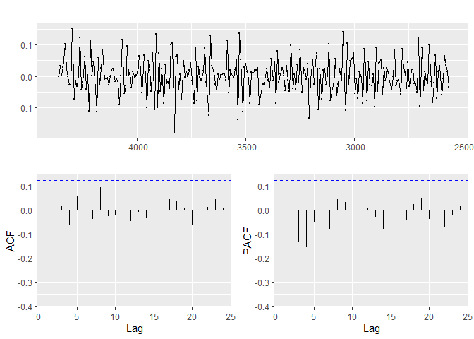

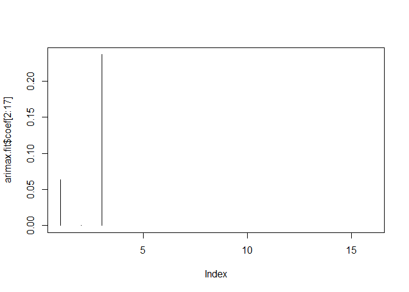

[output not shown]